# Space-time covariance functions

April 22, 2015

As discussed in [Stein, *Space-Time Covariance Functions*, 2005], replacing the $L^2$ norms with other $L^\gamma$, for $\gamma<2$ can produce “ridges” in the covariance function: if $K(x,t) \approx K(x,0) + C |t|^\delta$ for some $0 < \delta < 2$, thus making $K(x,t)$ have discontinuous derivative at $t=0$ even for spatial displacements $x \neq 0$; it turns out that this implies that “small changes in the locations of observations can lead to large changes in correlations between certain linear combinatoins of observations”. Therefore, Stein argues that covariance functions that are smooth away from the origin (but may be nonsmooth at $(x,t)=(0,0)$) are desireable.

A flexible class proposed in that paper has spectral density $f(u,v) = \frac{1}{\left( a_1 + c_1 v^2 + c_2(a_2 + \|u\|^2)^{\alpha_2} \right)^\nu},$ where $v$ is the Fourier variable corresponding to time and $u$ is the Fourier variable corresponding to space. In terms of the spectral density, $K(x,t) = \int_{\mathbb{R}^d} e^{i u \cdot x} \int_{\mathbb{R}} e^{i v t } f(u,v) dv du.$ Stein gives an analytic form for the Fourier transform over $x$, but notes that other methods would be needed to finish the transform.

However, later on (equation (11)), he introduces a fairly general class of covariance functions that hold for, in particular, a set of spatial, Markovian, Gaussian processes. These are parameterized by positive numbers $\alpha$, $\nu$, and $\zeta$, a number $\epsilon$, and a unit vector $z \in \mathbb{R}^d$, and are given by: $K(x,t) = \frac{ \pi^{d/2} \alpha^d }{ 2^{\nu+\zeta|t|-1} \Gamma(\nu + \zeta|t| + d/2)} \mathcal{M}_{\nu + \zeta|t|}(\alpha\|x - \epsilon t z\|),$ where $\Gamma$ is the gamma function, $\mathcal{M}$ is the Matern function, $\mathcal{M}_{\nu}(r) = r^\nu \mathcal{K}_\nu(r),$ where $\mathcal{K}_\nu$ is the modified Bessel function of order $\nu$, implemented in R as `gsl::bessel_Knu` (note also `gsl::bessel_Knu_scaled` and `gsl::bessel_lnKnu`, which might be more efficient). Note that $\nu$ controls the smoothness of the covariance function near zero, and hence the degree of differentiability; if we could work out the desired degree of smoothness, this would specify $\nu$. Furthermore, Stein notes that: if $\epsilon \neq 0$, the model is not symmetric: $K(0,t)$ decays exponentially as $t \to \infty$, but $K(\epsilon t z,t)$ decays as $|t|^{d/2}$.

There are other resources for the Matern family, see e.g. [this paper](http://www.sciencedirect.com/science/article/pii/S0098300408000666) in geostatistics, that fits such a model using weighted least squares, including a nugget, but purely spatial data, I think. Also, see [google](https://scholar.google.com/scholar?as_ylo=2014&q=matern+spatiotemporal&hl=en&as_sdt=0,5).

Will this take longer? Well, as a quick check:

```r
microbenchmark(exp(-3))
```

```
## Unit: nanoseconds
##     expr min    lq   mean median    uq  max neval
##  exp(-3) 543 560.5 673.32  571.5 662.5 6530   100
```

```r
microbenchmark(bessel_Knu(nu=1.4,x=-3))
```

```
## Unit: microseconds
##                          expr     min       lq     mean   median       uq
##  bessel_Knu(nu = 1.4, x = -3) 102.862 105.5555 121.4375 108.7155 127.7925
##      max neval
##  454.066   100
```

… yes, `exp` is a lot quicker than `bessel_Knu`… but, this is likely to be only a small portion of the computation time.

## Implementation

```r
spatiotemporal.covariance <- function(geo.dist,time.dist,alpha,nu,zeta){
    d <- 2  # two spatial dimensions
    return( exp(
            d/2 * log(pi) +
            d * log(alpha) -
            ( (nu + zeta*time.dist - 1)*log(2) +
                    gsl::lngamma(nu + zeta*time.dist + d/2)
                ) +
            nu * log(alpha*geo.dist) +
            gsl::bessel_lnKnu(nu=nu,x=alpha*geo.dist)
    ) )
}
```

Let’s see what it looks like:

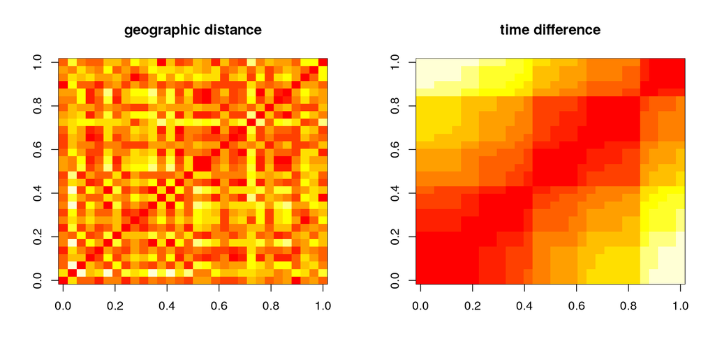

```r
set.seed(11113)
k <- 30
n.loci <- 1e6
spatial.coords <- cbind(runif(k),runif(k))
temporal.coords <- sort(runif(k))
geo.dist <- fields::rdist(spatial.coords)
time.dist <- fields::rdist(temporal.coords)
layout(t(1:2))
image(geo.dist,main="geographic distance")
image(time.dist,main="time difference")
```

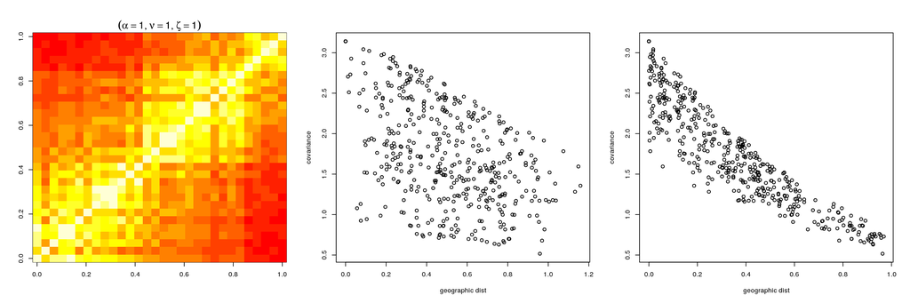

```r
layout(t(1:3))
plot.fn <- function (alpha,nu,zeta) {
    covmat <- spatiotemporal.covariance(geo.dist,time.dist,alpha=alpha,nu=nu,zeta=zeta)
    image(covmat)
    mtext( substitute( group( "(", list( alpha == alphaval, nu == nuval, zeta == zetaval ), ")" ), list(alphaval=alpha, nuval=nu, zetaval=zeta) ), side=3 )
    plot( geo.dist, as.vector(covmat), xlab="geographic dist", ylab="covariance" )
    plot( time.dist, as.vector(covmat), xlab="geographic dist", ylab="covariance" )
}

plot.fn( alpha=1, nu=1, zeta=1 )
```

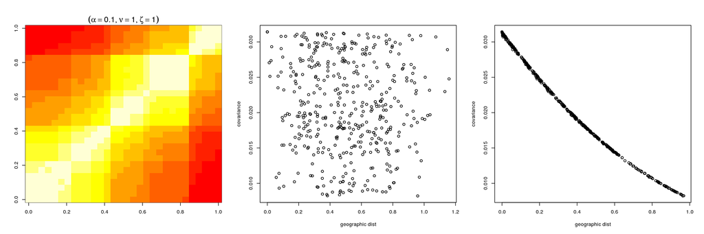

```r
plot.fn( alpha=.1, nu=1, zeta=1 )
```

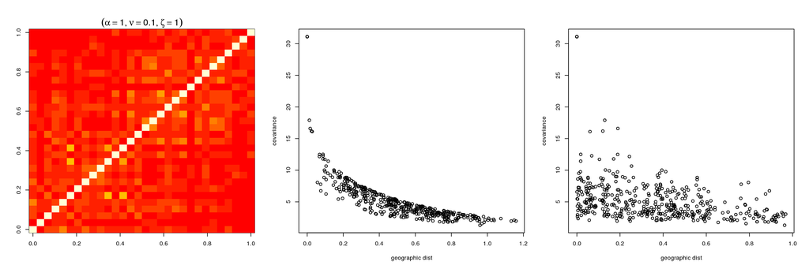

```r
plot.fn( alpha=1, nu=.1, zeta=1 )
```

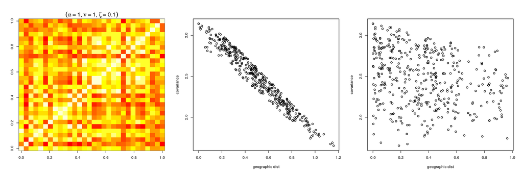

```r
plot.fn( alpha=1, nu=1, zeta=.1 )
```